# Laplacian Eigenmaps and Spectral Techniques for Embedding and Clustering

Paper Authors: Mikhail Belkin and Partha Niyogi

Noah Geller

2025-02-05

# Background and Motivation

- “The Manifold Hypothesis” $\longrightarrow$ Dimensionality Reduction.
- Goal: A dimension reduction technique that reflects the geometry of the data.
- Key Idea:
  $$\begin{align*}\text{Graphs } &\longleftrightarrow \text{ Manifolds}\\ \text{Graph Laplacian } &\longleftrightarrow \text{ Laplace-Beltrami Operator}\end{align*}$$

# Table of Contents

1) Algorithm

$$\text{Dataset}\rightarrow \text{Weighted Graph} \rightarrow \text{Low Dim. Embedding}$$

2) Justification

$$\text{Why this is a good idea and how to choose the weights.}$$

3) Examples

# The Algorithm

## Structure of the Algorithm

- Input: A dataset of $k$-points $x_1,\dots,x_k\in \mathbb{R}^\ell$ and an integer $m < \ell$.
- Use the ‘closeness’ of points to turn the dataset into a graph.
- Weight the edges of this graph.
- Do some linear algebra on the Laplacian and the weight matrix.
- Output: Vectors $v_1,\dots,v_k\in \mathbb{R}^m$, where $v_i$ is the lower dimensional representation of $x_i$.

## Constructing the Graph

- Two primary choices for drawing edges:
  - $\varepsilon$-Neighborhoods
    - Choose $\varepsilon > 0$.
    - $x_i\sim x_j \longleftrightarrow ||x_i-x_j||^2 < \varepsilon$.
    - Pro: Makes sense geometrically.
    - Cons: Hard to choose $\varepsilon$ and usually leads to many connected components.

## Constructing the Graph

- Two primary choices for drawing edges:
  - $N$-Nearest-Neighbors
    - Choose $N>0$.
    - $x_i\sim x_j$ if $x_i$ is one of the $N$ nearest neighbors of $x_j$ or vice versa.
    - Pros: Easier to choose $N$ than $\varepsilon$. Usually leads to connected graphs.
    - Con: Harder to understand in terms of geometry.

## Weighting the Graph

- Choose a real number parameter $t>0$.
- Construct a weight matrix $W_{ij}$ using the heat kernel:

$$W_{ij} = \begin{cases}e^{-\frac{||x_i-x_j||^2}{t}} \text{ if } x_i\sim x_j \\
0 \text{ otherwise}\end{cases}$$

## Get Laplacian Matrix

- Let $D$ be the diagonal weighted degree matrix
  $$D_{ii} = \sum_{i,j}W_{i,j} = \sum_{j,i}W_{j,i}.$$
- The Laplacian matrix is given by
  $$L = D - W.$$
- This is basically a weighted version of
  $$L = D - A.$$

## Recap

- Take the data points $x_1,\dots,x_k$ and make a graph where you put edges between ‘close’ points.
- Weight the edges based on the distance, using the heat kernel.
- Calculate the Laplacian
  $$L = D - W.$$

## Key Step

- Solve the ‘eigenvector’ problem
  $$Ly = \lambda Dy \longleftrightarrow Dy - Wy = \lambda Dy$$
- Get solutions $y_0,\dots,y_{k-1}\in \mathbb{R}^k$ ordered by $\lambda$ (from least to greatest).
- Output: The $m$-dimensional embedding of a data point $x_i$ is
  $$(y_1(i),\dots,y_m(i)).$$

# Justification

## What makes a good coordinate function?

- Have a weighted graph $G$.
- Want a function $f:G\to \mathbb{R}$ such that connected points stay close together.
- Minimization Problem (will need to add a constraint later):
  $$\sum_{i,j}W_{ij}(f(x_i)-f(x_j))^2.$$

## Relationship to the Laplacian

- Let $y_i=f(x_i)$.
- $y^TDy = \displaystyle\sum_{i} D_{ii} y_i^2 = \sum_{i,j}y_i^2W_{ij}$
- $y^TWy = \displaystyle \sum_{i,j}y_i y_j W_{ij}$

$$\begin{align*}
\sum_{i,j}(y_i^2 - 2y_i y_j + y_j^2)W_{ij} &= 2\sum_{i,j} y_i^2W_{ij} - 2\sum_{i,j}y_i y_jW_{ij}\\ &= 2(y^TDy - y^TWy) \\ &= 2y^TLy.
\end{align*}$$

## New Optimization Goal

- Minimize $y^T L y$.
- Need to add constraint: $y^TDy=1$.
- Now we need to solve:
  $$Ly = \lambda Dy.$$
- Ignore constant function with $\lambda = 0$.
- Generalization:
  $$Y = \text{argmin}_{Y^TDY=I}tr(Y^TLY)$$

# Manifolds: The Laplace-Beltrami Operator

## The Analagous Problem

- Let $M$ be a smooth $m$-dimensional manifold embedded in Euclidean space.
- Want to find $f:M\to \mathbb{R}$ which minimizes
  $$\int_M ||\nabla f||^2.$$
- This is the continuous version of
  $$\sum_{i,j}(f(x_i)-f(x_j))^2W_{ij}.$$

## Relation to Laplacian

$$\int_M ||\nabla f||^2 = \int_M \langle \nabla f , \nabla f \rangle = \int_M -\text{div}(\nabla f)f = \int_M -\mathcal{L}(f)f.$$

$$\text{ }$$
$$\text{ }$$

$$\implies f \text{ should be an eigenfunction of }\mathcal{L}(g) = \text{div}(\nabla g)$$

## Why the Heat Kernel?

- Let $f:M\to \mathbb{R}$ be an initial heat distribution.
- Let $u(x,t)$ be the heat distribution at time $t$, so $u(x,0)=f(x)$.
- The Heat Equation: $\frac{\partial u}{\partial t} = \mathcal{L}u$

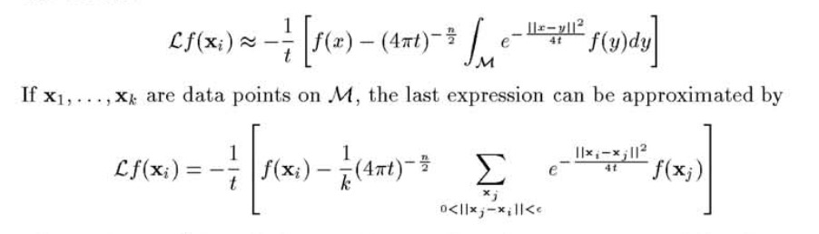

# Example

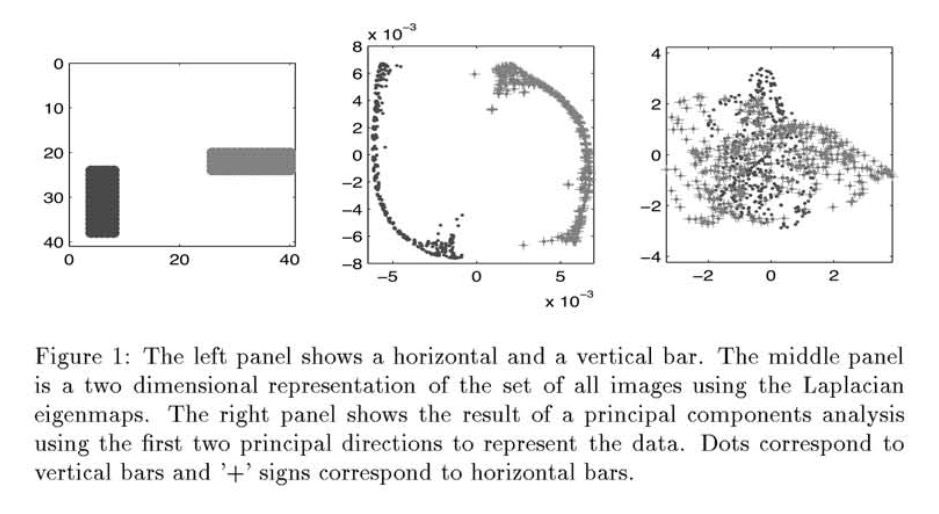